# Loading the Data

In this section, I load the test and train data.

```r
set.seed(4512);
TrainDataUrl<- "http://d396qusza40orc.cloudfront.net/predmachlearn/pml-training.csv";
TestDataUrl<- "http://d396qusza40orc.cloudfront.net/predmachlearn/pml-testing.csv";
TrainData<- read.csv(url(TrainDataUrl), na.strings=c("NA","#DIV/0!",""));
TestData<- read.csv(url(TestDataUrl), , na.strings=c("NA","#DIV/0!",""));
```

# Cleaning the Data

I remove columns of NAs as well as the first 7 features of the TestData and TrainData.

```r
# Remove columns full of NAs
features <- names(TestData[,colSums(is.na(TestData)) == 0])[8:59];
# Only use features used in TestData
TrainData <- TrainData[,c(features,"classe")];
TestData <- TestData[,c(features,"problem_id")];
```

# Bootstrap

I withhold 30% of the dataset as my own test data

```r
inTrain <- createDataPartition(TrainData$classe, p=0.70, list=FALSE);
myTraining <- TrainData[inTrain, ];
myTesting <- TrainData[-inTrain, ];
dim(myTraining)
```

```
## [1] 13737    53
```

```r
dim(myTesting)
```

```
## [1] 5885   53
```

# Feature selection

To deal with correlated features, I ignore features that are highly correlated. The cut-off threshold was set at correlation coefficient > 90%.

```r
outcome = which(names(myTraining) == "classe");
highCorr = findCorrelation(abs(cor(myTraining[,-outcome])),0.90);
highCorrNames = names(myTraining)[highCorr];
myTraining = myTraining[,-highCorr];
outcome = which(names(myTraining) == "classe");
```

The following 7 features were removed due to high correlation: accel_belt_z, roll_belt, accel_belt_y, accel_belt_x, gyros_arm_y, gyros_forearm_z, and gyros_dumbbell_x.

# Feature exploration

The random forest method is great for nonlinear features. In order to verify feature non-linerity, I first use random forest to discover the most important features. Below is the feature plot for the most important features.

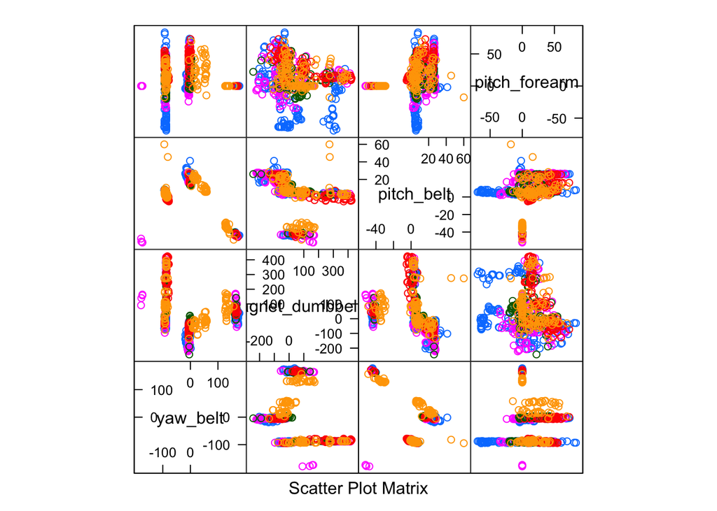

```r
fsRF = randomForest(myTraining[,-outcome], myTraining[,outcome], importance = TRUE)
RFimp = data.frame(fsRF$importance);
impF = order(-RFimp$MeanDecreaseGini);
inImp = createDataPartition(TrainData$classe, p = 0.05, list = FALSE);
featurePlot(myTraining[inImp,impF[1:4]],myTraining$classe[inImp], plot = "pairs")
```

# Training

Here I train using both random forest and k-nearest neighbors.

```r
ctrlKNN = trainControl(method = "adaptive_cv")
modelKNN = train(classe ~ ., myTraining, method = "knn", trControl = ctrlKNN)
ctrlRF = trainControl(method = "oob")
modelRF = train(classe ~ ., myTraining, method = "rf", ntree = 200, trControl = ctrlRF)
resultsKNN = data.frame(modelKNN$results)
resultsRF = data.frame(modelRF$results)
```

# Testing out-of-sample error

```r
fitKNN = predict(modelKNN, myTesting)
fitRF = predict(modelRF, myTesting)
KNNAccuracy = confusionMatrix(fitKNN, myTesting$classe)
KNNAccuracy
```

```
## Confusion Matrix and Statistics
##
##           Reference
## Prediction    A    B    C    D    E
##          A 1615   57   19   11   13
##          B   14  970   37    8   41
##          C   17   52  915   70   32
##          D   23   37   34  865   31
##          E    5   23   21   10  965
##
## Overall Statistics
##
##                Accuracy : 0.9057
##                  95% CI : (0.8979, 0.913)
##     No Information Rate : 0.2845
##     P-Value [Acc > NIR] : < 2.2e-16
##
##                   Kappa : 0.8807
##  Mcnemar's Test P-Value : 3.756e-14
##
## Statistics by Class:
##
##                      Class: A Class: B Class: C Class: D Class: E
## Sensitivity            0.9648   0.8516   0.8918   0.8973   0.8919
## Specificity            0.9763   0.9789   0.9648   0.9746   0.9877
## Pos Pred Value         0.9417   0.9065   0.8425   0.8737   0.9424
## Neg Pred Value         0.9859   0.9649   0.9769   0.9798   0.9759
## Prevalence             0.2845   0.1935   0.1743   0.1638   0.1839
## Detection Rate         0.2744   0.1648   0.1555   0.1470   0.1640
## Detection Prevalence   0.2914   0.1818   0.1845   0.1682   0.1740
## Balanced Accuracy      0.9705   0.9153   0.9283   0.9360   0.9398
```

```r
RFAccuracy = confusionMatrix(fitRF, myTesting$classe)
RFAccuracy
```

```
## Confusion Matrix and Statistics
##
##           Reference
## Prediction    A    B    C    D    E
##          A 1673    8    0    0    0
##          B    1 1126   11    0    0
##          C    0    4 1011    7    1
##          D    0    1    4  956    2
##          E    0    0    0    1 1079
##
## Overall Statistics
##
##                Accuracy : 0.9932
##                  95% CI : (0.9908, 0.9951)
##     No Information Rate : 0.2845
##     P-Value [Acc > NIR] : < 2.2e-16
##
##                   Kappa : 0.9914
##  Mcnemar's Test P-Value : NA
##
## Statistics by Class:
##
##                      Class: A Class: B Class: C Class: D Class: E
## Sensitivity            0.9994   0.9886   0.9854   0.9917   0.9972
## Specificity            0.9981   0.9975   0.9975   0.9986   0.9998
## Pos Pred Value         0.9952   0.9895   0.9883   0.9927   0.9991
## Neg Pred Value         0.9998   0.9973   0.9969   0.9984   0.9994
## Prevalence             0.2845   0.1935   0.1743   0.1638   0.1839
## Detection Rate         0.2843   0.1913   0.1718   0.1624   0.1833
## Detection Prevalence   0.2856   0.1934   0.1738   0.1636   0.1835
## Balanced Accuracy      0.9988   0.9930   0.9915   0.9951   0.9985
```

The random forest fit is obviously more accurate than the k-nearest neighbors method with 99% accuracy.